# Week 6 Application Exercise - KEY

Prof. Amanda D. Perez, PhD

# Introduction

**Be sure to set** `EVAL = TRUE` **for all of the code chunks that have** `EVAL = FALSE` **.**

This week we will be doing both cross-validation and bootstrapping. In this introduction section I will be doing some data cleaning to prepare for your task of cross-validation and bootstrapping. This means that for this introductory section you do not have to change any of the code, just run it.

We will be using data from The Office.

Specifically, we will use `theoffice` data from the [**schrute**](https://bradlindblad.github.io/schrute/) package to predict IMDB scores for episodes of The Office.

First, let’s load our packages.

```r
library(tidyverse)
library(tidymodels)
library(schrute)
library(lubridate)
library(psych)
```

Second, let’s take a glimpse at the data.

```r
glimpse(theoffice)
```

```
## Rows: 55,130
## Columns: 12
## $ index            <int> 1, 2, 3, 4, 5, 6, 7, 8, 9, 10, 11, 12, 13, 14, 15, 16…
## $ season           <int> 1, 1, 1, 1, 1, 1, 1, 1, 1, 1, 1, 1, 1, 1, 1, 1, 1, 1,…
## $ episode          <int> 1, 1, 1, 1, 1, 1, 1, 1, 1, 1, 1, 1, 1, 1, 1, 1, 1, 1,…
## $ episode_name     <chr> "Pilot", "Pilot", "Pilot", "Pilot", "Pilot", "Pilot",…
## $ director         <chr> "Ken Kwapis", "Ken Kwapis", "Ken Kwapis", "Ken Kwapis…
## $ writer           <chr> "Ricky Gervais;Stephen Merchant;Greg Daniels", "Ricky…
## $ character        <chr> "Michael", "Jim", "Michael", "Jim", "Michael", "Micha…
## $ text             <chr> "All right Jim. Your quarterlies look very good. How …
## $ text_w_direction <chr> "All right Jim. Your quarterlies look very good. How …
## $ imdb_rating      <dbl> 7.6, 7.6, 7.6, 7.6, 7.6, 7.6, 7.6, 7.6, 7.6, 7.6, 7.6…
## $ total_votes      <int> 3706, 3706, 3706, 3706, 3706, 3706, 3706, 3706, 3706,…
## $ air_date         <fct> 2005-03-24, 2005-03-24, 2005-03-24, 2005-03-24, 2005-…
```

## Data Cleaning

Below I will go through some data cleaning steps to prepare the data for our cross-validation and bootstrapping.

### Step 1

Fix `air_date` for later use.

```r
theoffice <- theoffice %>%
  mutate(air_date = ymd(as.character(air_date)))
```

### Step 2 - Calculate the percentage of lines spoken by Jim, Pam, Michael, and Dwight for each episode of The Office.

```r
office_lines <- theoffice %>%
  group_by(season, episode) %>%
  mutate(
    n_lines = n(),
    lines_jim = sum(character == "Jim") / n_lines,
    lines_pam = sum(character == "Pam") / n_lines,
    lines_michael = sum(character == "Michael") / n_lines,
    lines_dwight = sum(character == "Dwight") / n_lines,
  ) %>%
  ungroup() %>%
  select(season, episode, episode_name, contains("lines_")) %>%
  distinct(season, episode, episode_name, .keep_all = TRUE)
```

### Step 3 - Identify episodes that touch on Halloween, Valentine’s Day, and Christmas.

```r
theoffice <- theoffice %>%
  mutate(text = tolower(text))
halloween_episodes <- theoffice %>%
  filter(str_detect(text, "halloween")) %>%
  count(episode_name) %>%
  filter(n > 1) %>%
  mutate(halloween = 1) %>%
  select(-n)
valentine_episodes <- theoffice %>%
  filter(str_detect(text, "valentine")) %>%
  count(episode_name) %>%
  filter(n > 1) %>%
  mutate(valentine = 1) %>%
  select(-n)
christmas_episodes <- theoffice %>%
  filter(str_detect(text, "christmas")) %>%
  count(episode_name) %>%
  filter(n > 1) %>%
  mutate(christmas = 1) %>%
  select(-n)
```

### Step 4 - Put together a modeling dataset that includes features you’ve engineered. Also add an indicator variable called `michael` which takes the value `1` if Michael Scott (Steve Carrell) was there, and `0` if not. Note: Michael Scott (Steve Carrell) left the show at the end of Season 7.

```r
office_df <- theoffice %>%
  select(season, episode, episode_name, imdb_rating, total_votes, air_date) %>%
  distinct(season, episode, .keep_all = TRUE) %>%
  left_join(halloween_episodes, by = "episode_name") %>%
  left_join(valentine_episodes, by = "episode_name") %>%
  left_join(christmas_episodes, by = "episode_name") %>%
  replace_na(list(halloween = 0, valentine = 0, christmas = 0)) %>%
  mutate(michael = if_else(season > 7, 0, 1)) %>%
  mutate(across(halloween:michael, as.factor)) %>%
  left_join(office_lines, by = c("season", "episode", "episode_name"))
```

### Step 5 - Take a look at the new dataset

```r
glimpse(office_df)
```

```
## Rows: 186
## Columns: 14
## $ season        <int> 1, 1, 1, 1, 1, 1, 2, 2, 2, 2, 2, 2, 2, 2, 2, 2, 2, 2, 2,…
## $ episode       <int> 1, 2, 3, 4, 5, 6, 1, 2, 3, 4, 5, 6, 7, 8, 9, 10, 11, 12,…
## $ episode_name  <chr> "Pilot", "Diversity Day", "Health Care", "The Alliance",…
## $ imdb_rating   <dbl> 7.6, 8.3, 7.9, 8.1, 8.4, 7.8, 8.7, 8.2, 8.4, 8.4, 8.2, 8…
## $ total_votes   <int> 3706, 3566, 2983, 2886, 3179, 2852, 3213, 2736, 2742, 27…
## $ air_date      <date> 2005-03-24, 2005-03-29, 2005-04-05, 2005-04-12, 2005-04…
## $ halloween     <fct> 0, 0, 0, 0, 0, 0, 0, 0, 0, 0, 1, 0, 0, 0, 0, 0, 0, 0, 0,…
## $ valentine     <fct> 0, 0, 0, 0, 0, 0, 0, 0, 0, 0, 0, 0, 0, 0, 0, 0, 0, 0, 0,…
## $ christmas     <fct> 0, 0, 0, 0, 0, 0, 0, 0, 0, 0, 0, 0, 0, 0, 0, 1, 0, 0, 0,…
## $ michael       <fct> 1, 1, 1, 1, 1, 1, 1, 1, 1, 1, 1, 1, 1, 1, 1, 1, 1, 1, 1,…
## $ lines_jim     <dbl> 0.15720524, 0.12315271, 0.17213115, 0.20164609, 0.091304…
## $ lines_pam     <dbl> 0.17903930, 0.05911330, 0.13114754, 0.09053498, 0.060869…
## $ lines_michael <dbl> 0.3537118, 0.3694581, 0.2295082, 0.2798354, 0.4521739, 0…
## $ lines_dwight  <dbl> 0.12663755, 0.08374384, 0.25409836, 0.19341564, 0.108695…
```

# Cross-Validation

## Exercise 1

Create the `office_split` object and split the data into training (75%) and testing (25%). You will need to use the `initial_split()` function on our `office_df`.

```r
set.seed(1234) #set the seed so we can all reproduce results
office_split <- initial_split(office_df) # prop = 3/4 by default
```

## Exercise 2

Now you must use `office_split` and pull our the training and testing data from within it.

Create `office_train` with the `training()` function on our split data.

Create `office_test` with the `testing()` function on our split data.

```r
office_train <- training(office_split)
office_test  <- testing(office_split)
```

## Exercise 3

Next, using the tidymodels framework, specify your model and save it into the `office_mod` object. *Hint: You will use* `linear_reg()` *and specify the lm as the engine.*

```r
office_model <- linear_reg() %>%
  set_engine("lm")
```

## Exercise 4

Now it is time to build our recipe. In this step you must specify the model you want to run. The DV (outcome) will be `imdb_rating`. Your job is to look at the variables and select **two** to be your IVs (predictors). *Note: Do not use* `air_date` *or* `episode_name` *as your IV.*

```r
objects(office_train)
```

```
##  [1] "air_date"      "christmas"     "episode"       "episode_name"
##  [5] "halloween"     "imdb_rating"   "lines_dwight"  "lines_jim"
##  [9] "lines_michael" "lines_pam"     "michael"       "season"
## [13] "total_votes"   "valentine"
```

Fill in your IVs in the appropriate location in the code below.

```r
office_rec <- recipe(imdb_rating ~ halloween + christmas + episode_name, data = office_train) %>%
  update_role(episode_name, new_role = "id") %>%
  step_zv(all_predictors())
```

### Exercise 5

Build a workflow for fitting the model specified earlier and using the recipe you developed to preprocess the data. Add `office_model` and `office_rec` in the appropriate places in the below code.

```r
office_wflow <- workflow() %>%
  add_model(office_model) %>%
  add_recipe(office_rec)
```

### Exercise 6

Fit the model to training data and interpret the intercept and the slopes.

```r
office_fit <- office_wflow %>%
  fit(data = office_train)
tidy(office_fit)
```

```
## # A tibble: 3 x 5
##   term        estimate std.error statistic   p.value
##   <chr>          <dbl>     <dbl>     <dbl>     <dbl>
## 1 (Intercept)    8.22     0.0478   172.    5.33e-161
## 2 halloween1    -0.258    0.315     -0.819 4.14e-  1
## 3 christmas1     0.342    0.186      1.84  6.77e-  2
```

### Exercise 7

Perform 5-fold cross validation and view model performance metrics. Since we are doing a 5-fold, place `5` in the appropriate location in the below code. From the output, first interpret the `r-squared`.

```r
set.seed(1234)
folds <- vfold_cv(office_train, v = 5)
folds
```

```
## #  5-fold cross-validation
## # A tibble: 5 x 2
##   splits           id
##   <list>           <chr>
## 1 <split [111/28]> Fold1
## 2 <split [111/28]> Fold2
## 3 <split [111/28]> Fold3
## 4 <split [111/28]> Fold4
## 5 <split [112/27]> Fold5
```

```r
set.seed(4678)
office_fit_rs <- office_wflow %>%
  fit_resamples(folds)
collect_metrics(office_fit_rs)
```

```
## # A tibble: 2 x 6
##   .metric .estimator   mean     n std_err .config
##   <chr>   <chr>       <dbl> <int>   <dbl> <chr>
## 1 rmse    standard   0.536      5  0.0289 Preprocessor1_Model1
## 2 rsq     standard   0.0273     5  0.0126 Preprocessor1_Model1
```

**The RMSE is in the unit of the dependent variable. To be able to interpret the RMSE we must look at some descriptives for IMDB Ratings. See below for descriptives and use them to interpret the RMSE from the cross-validation output.**

```r
describe(office_train$imdb_rating)
```

```
##    vars   n mean   sd median trimmed  mad min max range skew kurtosis   se
## X1    1 139 8.24 0.54    8.2    8.24 0.59 6.7 9.7     3 0.03     0.33 0.05
```

### Exercise 8

Use your model to make predictions for the testing data and calculate the RMSE.

In the code below, fill in the blanks with the appropriate objects.

```r
office_test_pred <- predict(office_fit, new_data = office_test) %>%
  bind_cols(office_test %>% select(imdb_rating, episode_name))

rmse(office_test_pred, truth = imdb_rating, estimate = .pred)
```

```
## # A tibble: 1 x 3
##   .metric .estimator .estimate
##   <chr>   <chr>          <dbl>
## 1 rmse    standard       0.502
```

Interpret this RMSE. How doe this compare to the RMSE we got from the cross-validation of the training data? What does this mean?

## Exercise 9

Finally, you will compare your model to the model used during the lecture on cross-validation. Run the below code chunk and do not make any changes.

```r
office_mod_old <- linear_reg() %>%
  set_engine("lm")

office_rec_old <- recipe(imdb_rating ~ season + episode + total_votes + air_date, data = office_train) %>%
  # extract month of air_date
  step_date(air_date, features = "month") %>%
  step_rm(air_date) %>%
  # make dummy variables of month
  step_dummy(contains("month")) %>%
  # remove zero variance predictors
  step_zv(all_predictors())

office_wflow_old <- workflow() %>%
  add_model(office_mod_old) %>%
  add_recipe(office_rec_old)

office_fit_old <- office_wflow_old %>%
  fit(data = office_train)

tidy(office_fit_old)
```

```
## # A tibble: 12 x 5
##    term                estimate std.error statistic  p.value
##    <chr>                  <dbl>     <dbl>     <dbl>    <dbl>
##  1 (Intercept)         7.18     0.213        33.7   2.89e-65
##  2 season             -0.0482   0.0146       -3.30  1.24e- 3
##  3 episode             0.0347   0.0102        3.39  9.34e- 4
##  4 total_votes         0.000378 0.0000469     8.06  4.80e-13
##  5 air_date_month_Feb -0.0172   0.141        -0.122 9.03e- 1
##  6 air_date_month_Mar -0.184    0.146        -1.26  2.10e- 1
##  7 air_date_month_Apr -0.181    0.140        -1.30  1.98e- 1
##  8 air_date_month_May  0.0577   0.180         0.321 7.48e- 1
##  9 air_date_month_Sep  0.511    0.184         2.78  6.25e- 3
## 10 air_date_month_Oct  0.244    0.155         1.57  1.18e- 1
## 11 air_date_month_Nov  0.214    0.143         1.50  1.35e- 1
## 12 air_date_month_Dec  0.431    0.155         2.78  6.23e- 3
```

Your job is to fill in the blanks below. Your goal is to create `office_test_pred_old`. You want to make predictions with `office_fit_old` and use the new data of `office_test`. Then, you must fill in the blanks to run the `rmse()` command to see the RMSE for `office_test_pred_old`.

Which model did a better job in predicting IMDB scores for the testing data?

```r
office_test_pred_old <- predict(office_fit_old, new_data = office_test) %>%
  bind_cols(office_test %>% select(imdb_rating, episode_name))

rmse(office_test_pred_old, truth = imdb_rating, estimate = .pred)
```

```
## # A tibble: 1 x 3
##   .metric .estimator .estimate
##   <chr>   <chr>          <dbl>
## 1 rmse    standard       0.341
```

# Bootstrapping

Now we will shift gears to bootsrapping. There are many things we can bootstrap but the goal for this exercise will be to bootstrap the mean `imdb_rating`.

Below are the steps for bootstrapping:

1. Take a bootstrap sample - a random sample taken with replacement from the original sample, of the same size as the original sample
2. Calculate the bootstrap statistic - a statistic such as mean, median, proportion, slope, etc. computed on the bootstrap samples
3. Repeat steps (1) and (2) many times to create a bootstrap distribution - a distribution of bootstrap statistics
4. Calculate the bounds of the XX% confidence interval as the middle XX% of the bootstrap distribution

## Exercise 1

Fill in the blanks below to successfully create `office_boot`. You will need to take `office_df`, specify `imdb_rating` as the response, generate `15000` samples, and calculate the `mean`.

```r
set.seed(8888)
# save resulting bootstrap distribution
office_boot <- office_df %>%
  # specify the variable of interest
  specify(response = imdb_rating) %>%
  # generate 15000 bootstrap samples
  generate(reps = 15000, type = "bootstrap") %>%
  # calculate the mean of each bootstrap sample
  calculate(stat = "mean")
```

## Exercise 2

How many observations are there in `office_boot`? What does each observation represent?

```r
glimpse(office_boot)
```

```
## Rows: 15,000
## Columns: 2
## $ replicate <int> 1, 2, 3, 4, 5, 6, 7, 8, 9, 10, 11, 12, 13, 14, 15, 16, 17, 1…
## $ stat      <dbl> 8.226344, 8.295699, 8.205376, 8.226882, 8.237634, 8.253226, …
```

## Exercise 3

Visualize the bootstrap distribution. Below I have created a basic histogram. Your job is to: Add a theme, use both `color` and `fill` within the `geom_histogram()` function (see links for help), set the histogram `alpha = 0.5`, add a `geom_vline()` that has the value of the mean `office_boot$stat` and give it a `color` (see links below for help), Add a title, make the x axis say `Mean`, and finally make the y axis say `Frequency`.

[**Histogram Help**](http://www.sthda.com/english/wiki/ggplot2-histogram-plot-quick-start-guide-r-software-and-data-visualization#change-histogram-plot-line-types-and-colors)

[**Adding a Vertical Line Help**](https://www.rdocumentation.org/packages/ggplot2/versions/0.9.1/topics/geom_vline)

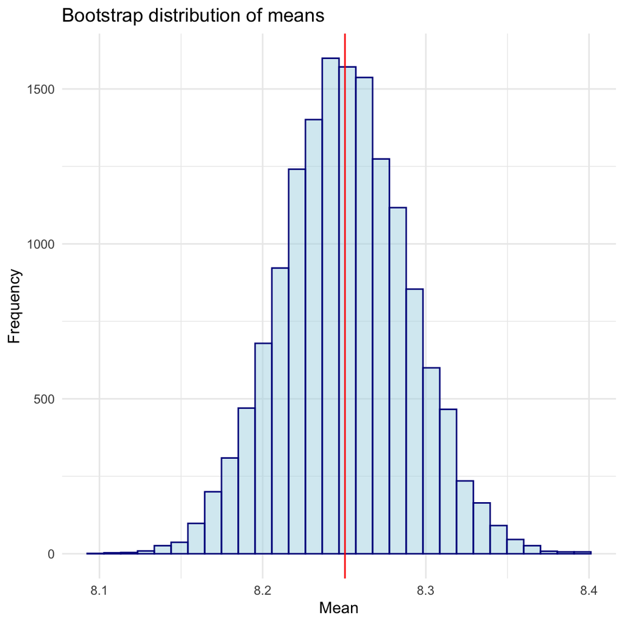

```r
ggplot(data = office_boot, mapping = aes(x = stat)) +
  geom_histogram(color="darkblue", fill="lightblue", alpha = 0.5) +
  geom_vline(xintercept = mean(office_boot$stat), color ="red")+
labs(title = "Bootstrap distribution of means", x = "Mean", y = "Frequency") +
  theme_minimal()
```

## Exercise 4

Calculate the confidence interval. A 95% confidence interval is bounded by the middle 95% of the bootstrap distribution. Fill in the values below.

```r
office_boot %>%
  summarize(lower = quantile(stat, 0.025),
            upper = quantile(stat, 0.975))
```

```
## # A tibble: 1 x 2
##   lower upper
##   <dbl> <dbl>
## 1  8.17  8.33
```

## Exercise 5

Copy and paste your histogram code from exercise 3. Your task is to add on an additional 2 lines, one for the lower 95% bound and one for the higher 95% bound. Make the line dashed *and* a different color than your line you already have for the mean.

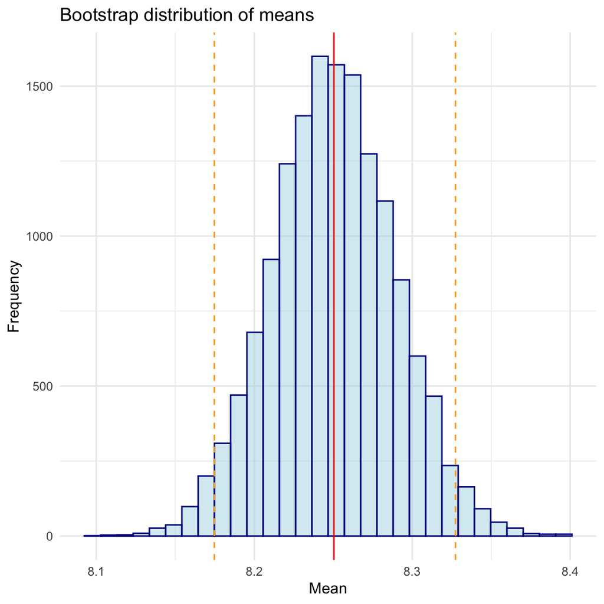

```r
ggplot(data = office_boot, mapping = aes(x = stat)) +
  geom_histogram(color="darkblue", fill="lightblue", alpha = 0.5) +
  geom_vline(xintercept = mean(office_boot$stat), color ="red") +
  geom_vline(xintercept = 8.174731, color ="orange", linetype = "dashed") +
  geom_vline(xintercept = 8.327419, color ="orange", linetype = "dashed") +
labs(title = "Bootstrap distribution of means", x = "Mean", y = "Frequency") +
  theme_minimal()
```

## Exercise 6

Your final task is to interpret what the 95% confidence bounds you calculated mean in the context of The Office’s IMDB Ratings.